# Homework notes

James Ibbetson

11/13/2017

## Disclaimer

**What follows contains solutions to course homework problems. It is intended as a historical record of (a) my thinking, and (b) useful R functions that are new to me. If you, the reader, are taking the course then STOP READING! Using what follows would constitute a violation of course policy.**

## Quiz 1

*If $F \equiv$ `father has flu`, $M \equiv$ `mother has flu`, and given $P(F)=0.12, P(F \cap M)=0.06, P(F \cup M)=0.17$ then what is the probability , $P(M)$ that `mother has flu`?*

$P(F \cup M) = P(F) + P(M) - P(F \cap M)$  
$\implies P(M) = P(F \cup M) - P(F) + P(F \cap M)$  
$\implies P(M) = 0.17 - 0.12 + 0.06 = 0.11$

*If $X \equiv$ `earnings` and there are two possible outcomes, $X_1 = X, X_2 = -Y$, with probability $P(X_1)=p$, then what has to be true so that the expected return is zero?*

$E[X] = \sum_x xp(x) = pX - (1-p)Y$ so for $E[X] = 0$ we need $pX = (1-p)Y \implies \frac{Y}{X} = p/(1-p)$.

*If $D \equiv$ `is pregnant`, $[+] \equiv$ `tested positive`, and $[-] \equiv$ `tested negative`, and given `prevalence` $= 0.3$, `sensitivity` $= 0.75$ and `specificity` $= 0.52$, then what is the probability of pregnancy given a positive test?*

`prevalence` $= P(D)$, `sensitivity` $= P(+|D)$, `specificity` $= P(-|D^c)$, and we need to solve for $P(D|+)$. To do so, use Bayes’ rule:

$P(D|+) = \frac{P(+|D)P(D)}{P(+|D)P(D)+P(+|D^c)P(D^c)}$

and note that  
$P(D^c)=1-P(D)=0.7$,  
$P(+|D^c)=1-P(-|D^c)=0.48$.

Substituting values into Bayes’ rule we get:  
$P(D|+) = \frac{0.75 \times 0.3}{0.75 \times 0.3 + 0.48 \times 0.7} \approx 40\%$.

## Quiz 2

*Suppose that diastolic blood pressures (DBPs) for men aged 35-44 are normally distributed with a mean of 80 (mm Hg) and a standard deviation of 10. What is the probability that a random 35-44 year old has a DBP less than 70?*

The answer is 16%. There are a few ways to get there.

First, recognize that 70 is one standard deviation from the mean. For the normal distribution $\pm 1\sigma$ contains 68% of the probability distribution. So 0.5 x (100%-68%) is 16%.

Second, do it graphically/numerically using `qnorm()`.

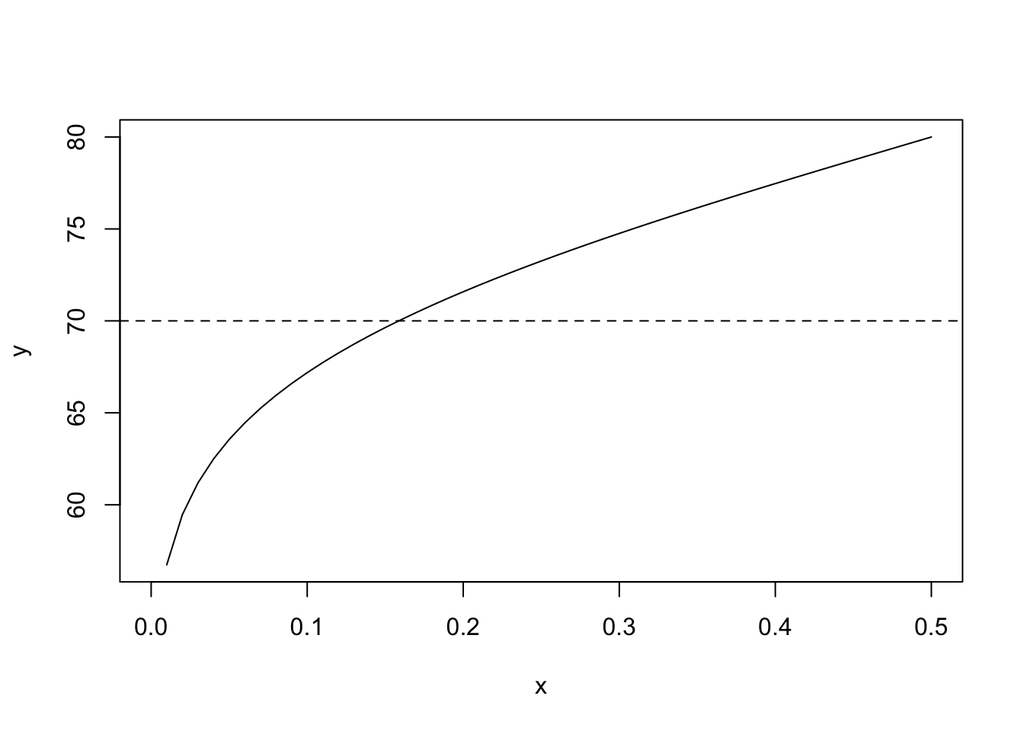

```r
x <- seq(0, 0.5, by = 0.01)
y <- qnorm(x, mean = 80, sd = 10)
plot(x, y, type = "l")
abline(h = 70, lty = 2)
```

Lastly, use `pnorm()`.

```r
pnorm(70, mean = 80, sd = 10)
```

```
## [1] 0.1586553
```

*Brain volume for adult women is normally distributed with a mean of about 1,100 cc for women with a standard deviation of 75 cc. What brain volume represents the 95th percentile?*

The answer is 1223. In R use `qnorm()` 0.95, mean = 1100, sd = 75)`. Or from the notes, the 95th percentile corresponds to 1100 + 1.645 x 75.

```r
qnorm(0.95, mean = 1100, sd = 75)
```

```
## [1] 1223.364
```

*Same dataset as the previous question. Consider the sample mean of 100 random adult women from this population. What is the 95th percentile of the distribution of that sample mean?*

$\sigma(\bar{X}) = \sqrt{Var(\bar{X})} = \sqrt{Var(X)}/\sqrt{n} = \sigma / \sqrt{n}$.

So in this case, $\sigma(\bar{X}) = \sigma / \sqrt{n} = 75/10$, and the answer is approximately 1112 cc. Use `qnorm(0.95, mean = 1100, sd = 7.5)`. Or the 95th percentile corresponds to mean + 1.645 x sd.

*You flip a fair coin 5 times, about what’s the probability of getting 4 or 5 heads?*

$\begin{aligned} P(X = x) = \binom{n}{x} p^x(1 - p)^{n-x} \end{aligned}$ where $\binom{n}{x} = \frac{n!}{x!(n-x)!}$  
So in this case we need $P(X = 4) | P(X = 5)$, which can be calculated manually. Or use `pbinom()` with the `lower.tail` parameter set to FALSE for $P(X > p)$. See `help` for details.

```r
pbinom(3, size = 5, prob = 0.5, lower.tail = FALSE)
```

```
## [1] 0.1875
```

*The respiratory disturbance index (RDI), a measure of sleep disturbance, for a specific population has a mean of 15 (sleep events per hour) and a standard deviation of 10. They are not normally distributed. Give your best estimate of the probability that a sample mean RDI of 100 people is between 14 and 16 events per hour?*

$\sigma(\bar{X}) = \sigma\div\sqrt{n} = 1$ in this case. So 14-16 events is $\pm 1 \sigma = 68\%$. Alternatively use `pnorm()`.

```r
pnorm(16, mean = 15, sd = 1) - pnorm(14, mean = 15, sd = 1)
```

```
## [1] 0.6826895
```

*The number of people showing up at a bus stop is assumed to be Poisson with a mean of 5 people per hour. You watch the bus stop for 3 hours. About what’s the probability of viewing 10 or fewer people?*

Since it’s a rate problem, use the Poisson distribution. See `help` for details of `ppois()`.

```r
ppois(10, lambda = 5 * 3)
```

```
## [1] 0.1184644
```